# Day 3

Dec 5, 2018

## Outline

Unsupervised analysis

Statistical analysis without any knowledge for the labeling of samples

The main aim is to find subgroups

- Dimension reduction
  - Principle component analysis (PCA)
  - Multiple dimensional scaling (MDS)
- Clustering
  - hierarchical clustering
  - partitioning (k-means)
  - model-based clustering
  - density-based clustering
  - consensus clustering

## Dimension reduction

Typically an expression matrix with n genes and m samples (n rows, m columns). If the aim is to analysis samples, for statistical analysis, the matrix is a data of **n dimensions**.

when n = 2, each sample can be represented as a data point in x-y coordinate system (2-dimensional coordinate system)

when n = 3, each sample is a point in a x-y-z coordinate system (3-dimensional).

when n > 3, each sample is a point in a high-dimensional coordinate system that we can not visualize.

Dimension reduction is an approach to reduce the data from n dimensions to 2 dimensions, which still tries to keep the major patterns of it.

**In the sense of programming, the dimension of the matrix is two.**

## Principle component analysis

PCA is the most commonly used dimension reduction method.

Assumption when you use PCA:

- variance is a measurement of the information of the data

What does the PCA do:

- It actually rotates the original n-dimension coordinate system to a new one where the data projected on the 1st axis shows highest variance.

The new axes are called the principle components.

Coordinate system rotation for a 2D dataset:

[figure not shown]

In PC1, the projected data points show highest variance.

M1 -> M2, where var(M2[, 1]) > var(M2[, 2])

Coordinate system rotation for a 3D dataset:

[figure not shown]

M1 -> M2, where var(M2[, 1]) > var(M2[, 2]) > var(M2[, 3])

Coordinate system rotation for a n-dimensional dataset:

M1 -> M2, where var(M2[, 1]) > var(M2[, 2]) > var(M2[, 3]) > … > var(M2[, n])

(actually the dimension of M2 is always the min(nrow(mat), ncol(mat)))

And we use M2[, 1:2] or M2[, 1:3] to represent the original M1.

The contribution of each principle componet:

\(p_i = var_i/\sum_i^K(var_i)\)

[figure not shown]

Things need to be noted for PCA analysis

- it does not detect subgroups
- we normally give points different colors/shapes according to known annotations.

[figure not shown]

R functions to perform PCA analysis:

```
fit = prcomp(t(mat))  # why do we need to transpose the matrix?
loc = fit$x[, 1:2]  # the first two PCs
plot(loc)
```

To calculate the contribution of variance for each PC:

```
all_var = apply(fit$x, 2, var)
all_var/sum(all_var)
```

## Multiple dimensional scaling

MDS also reduces the dimension of the data, but it works on the distance matrix (similarity matrix).

It tries to preserve the distance between data points also in low-dimension space.

## what is a distance matrix

Values in the distance matrix measures the "distance" or "similarity" between every two samples.

- Euclidean distance
- correlation distance (1 - cor, 1 - abs(cor))

check the documentation of "dist()" function

## Multiple dimensional scaling

In the distance matrix, \(d_{ij}\) is the distance between i and j in the n-dimension space

If we reduce into 2D, x and y, MDS aims to find a solution so that

\(dist( <x_i, y_i>, <x_j, y_j> ) \approx d_{ij}\)

M1 -> M_xy

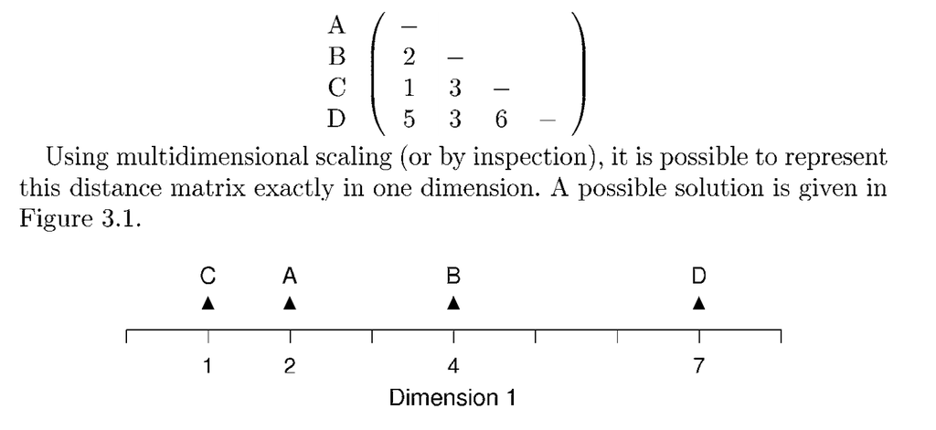

R functions to perform MDS analysis:

```
loc = cmdscale(dist(t(mat)), k = 2)
plot(loc)
```

## Compare PCA and MDS

- PCA is used more than MDS because PCA tells you the contribution of PC1 and PC2
- MDS directly works on the distance matrix, which means you can use any type of distance measurements
- PCA and MDS is identical if Euclidean distance is used for MDS.
  - PCA is a special case of MDS

## Clustering

- hierarchical clustering
- partitioning (k-means)
- model-based clustering
- density-based clustering
- consensus clustering

## Hierarchical clustering

It looks for the hierarchy of the similarity of samples.

First we find two data points that are closest.

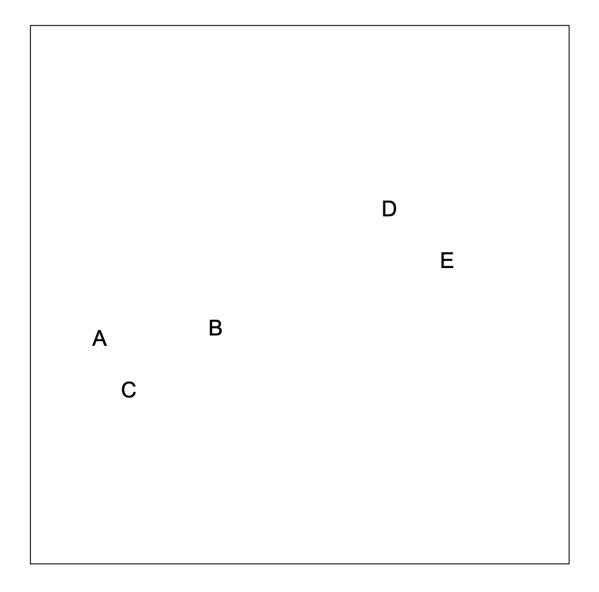

A and C are merged as a unit and we look for which two data points are closest in the "four" data points.

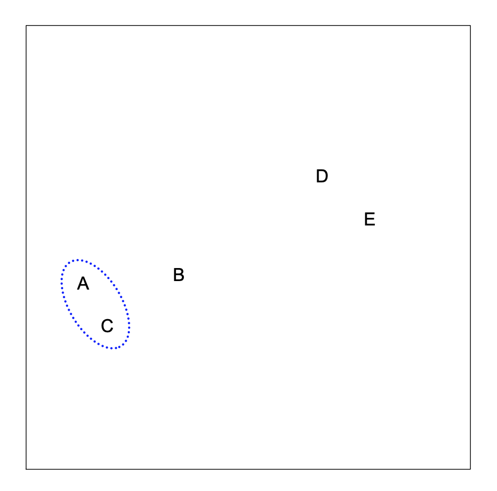

And we repeat this process ..,

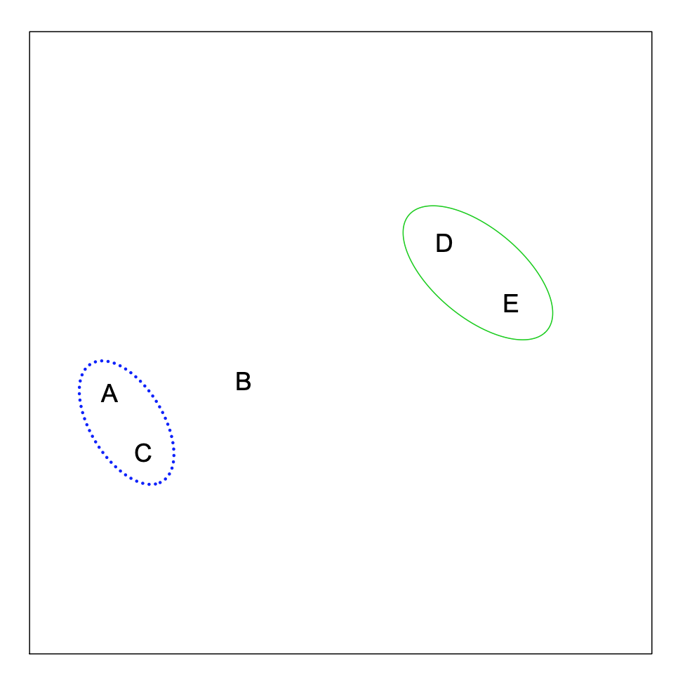

…

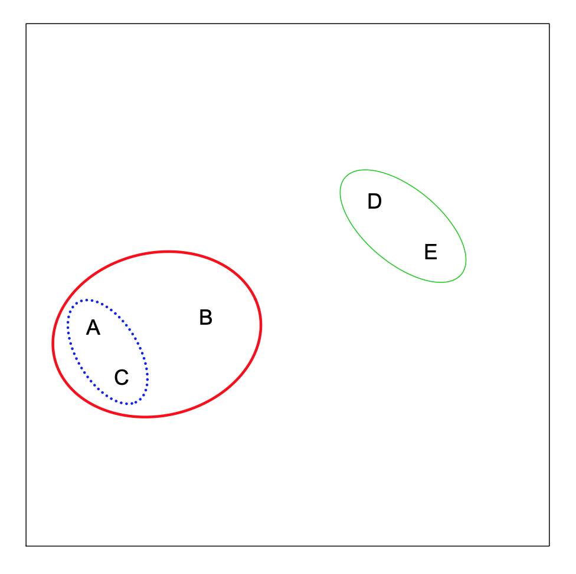

untile all the data points are included in the hierarchy.

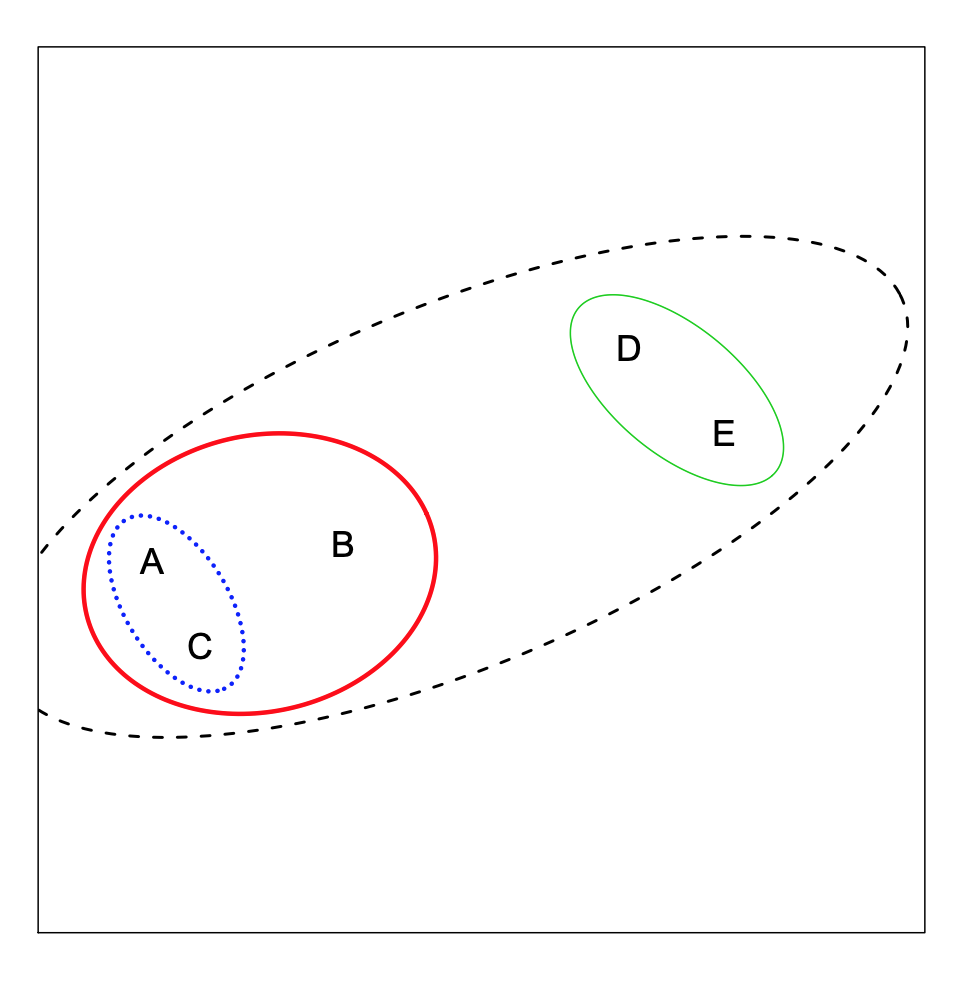

We can make this process as a tree (the dendrogram) where the height are the distance between two "data points".

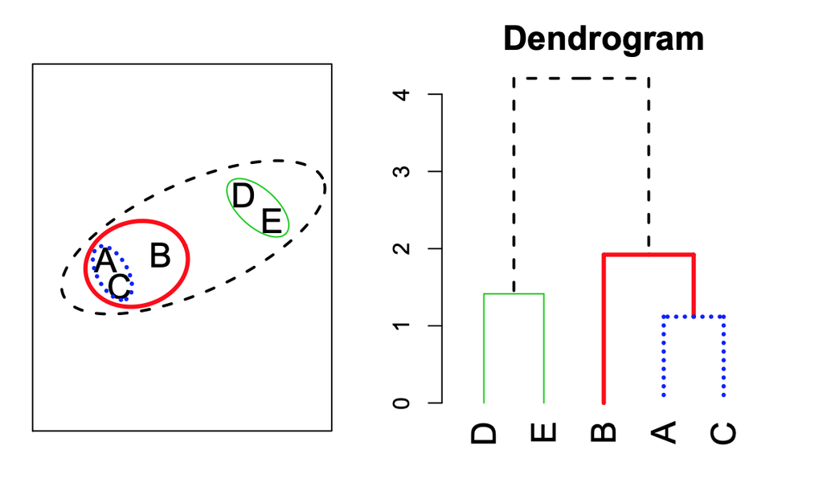

how to calculate distance of two clusters

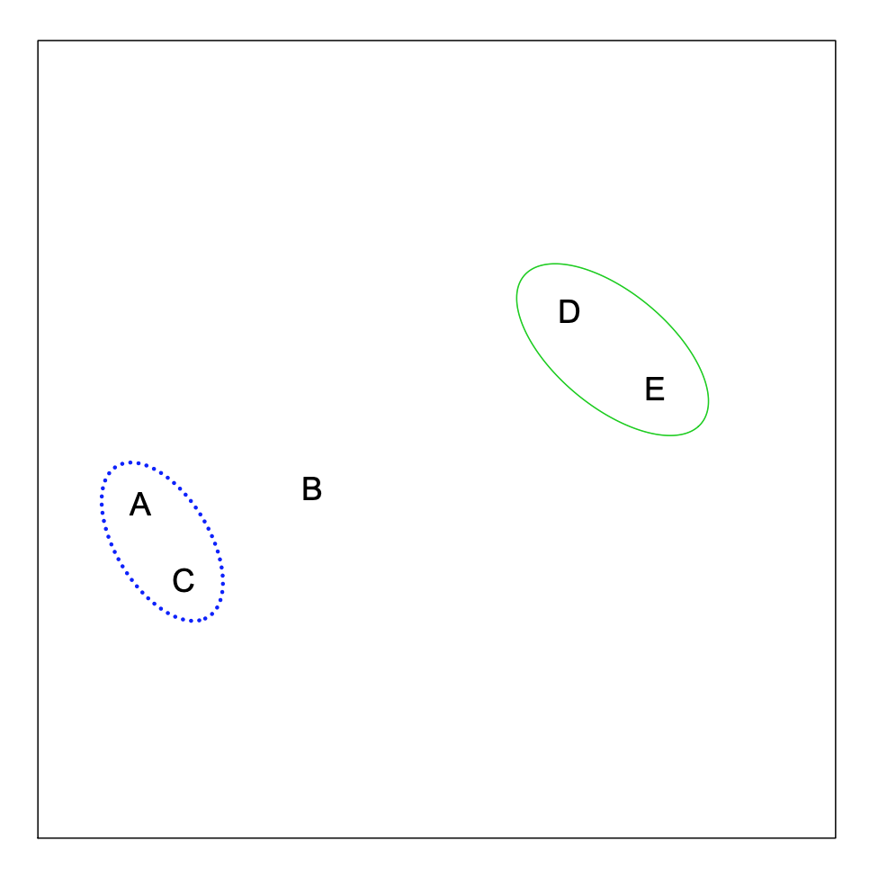

clustering method (linkage method):

- complete: max(d_AD, d_AE, d_CD, d_CE)
- single: min(d_AD, d_AE, d_CD, d_CE)
- average: mean(d_AD, d_AE, d_CD, d_CE)

Be careful different clustering methods give different dendrograms:

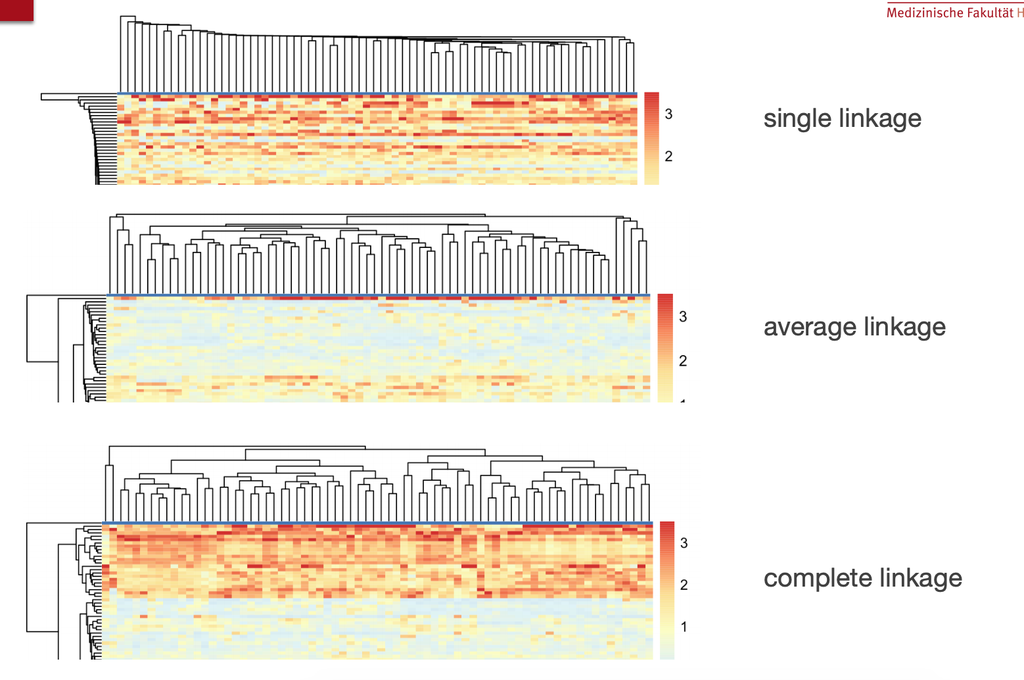

The dendrogram can be cut into k sub-clusters to separate samples into k groups (cutree).

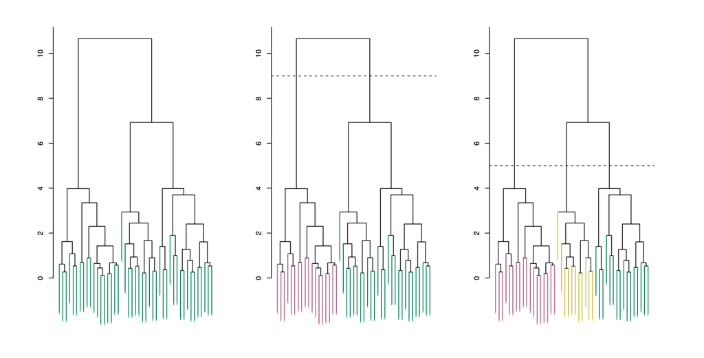

```
hc = hclust(dist(t(mat)))
plot(hc)
```

## k-means clustering

Put n data points into k groups, so that the within-cluster sum of squares (WCSS) is minimal:

\(\displaystyle {\underset {\mathbf {S} }{\operatorname {arg\,min} }}\sum _{i=1}^{k}\sum _{\mathbf {x} \in S_{i}}\left\|\mathbf {x} -{\boldsymbol {\mu }}_{i}\right\|^{2}\)

Basic steps:

1. decide k groups and random initialize k centers.
2. for each data point, calculate the distance to the k centers can label the cluster id to the nearest center.
3. since all data points are labelled with the k clusters, re-calculate the position of centers
4. repeat step 2 and 3, untile the labels not change

```
km = kmeans(t(mat), centers = 2)
km$cluster
```

[figure not shown]

how to select the number of clusters?

We can look at the sum of squared error for each k:

\(SSE = \sum_{i=1}^K\sum_{x \in c_i}dist(x, c_i)^2\)

where \(c_i\) is the center of each cluster.

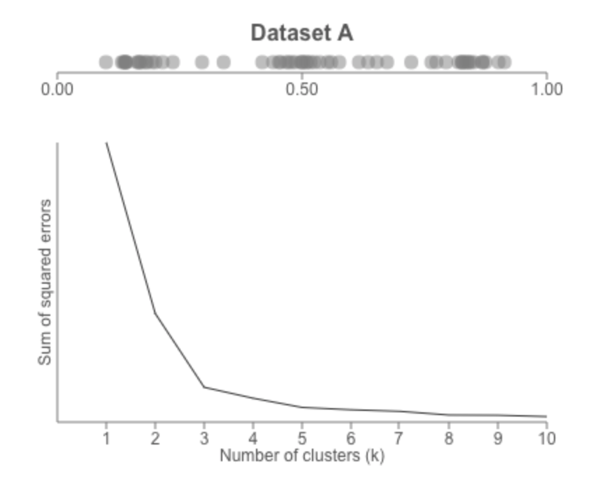

Some drakbacks for k-means clustering

k-means works best if the cluster is spherical

[figure not shown]

## model-based clustering

Try to fit the data with k multidimensional normal distribution.

[figure not shown]

## density-based clustering

[figure not shown]

For DBSCAN, you need to set the maximal distance to neighbourign points and the minimal number of neighbouring points.

[figure not shown]

## Consensus clustering

It checks the stability of the subgrouping.

Assume we have four subgrouping results by random sampling from the original data.

```
1 1 1 1 1 1 1   1 2 2 2    2 2
1 1 1 1 1 1 2   1 2 2 2    2 2
1 1 1 1 1 1 2   1 2 2 1    2 1
1 1 1 1 1 1 1   1 2 2 2    2 1
```

```
1 1 1 1 1 1 0.5 1 0 0 0.25 0 0.5  # belong to group 1
0 0 0 0 0 0 0.5 0 1 1 0.75 1 0.5  # belong to group 2
            ~~~              ~~~
```

consensus subgroup

```
1 1 1 1 1 1 ?   1 2 2  2   2 ?
```